# Лабораторная работа №2

Операционные системы

Бызова Мария Олеговна, НПИбд-01-23.

Российский университет дружбы народов, Москва, Россия

21 февраля 2024.

## Цель работы

Целью данной лабораторной работы является изучение идеологии и применение средств контроля версий, освоение умения по работе с git.

## Задание

1. Создать базовую конфигурацию для работы с git.
2. Создать ключ SSH.
3. Создать ключ PGP.
4. Настроить подписи git.
5. Зарегистрироваться на Github.
6. Создать локальный каталог для выполнения заданий по предмету.

## Установка программного обеспечения.

Уставливаю необходимое программное обеспечение: устанавливаю git (рис. 1).

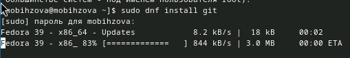

Установка git

## Установка программного обеспечения

Устанавливаю gh (рис. 2).

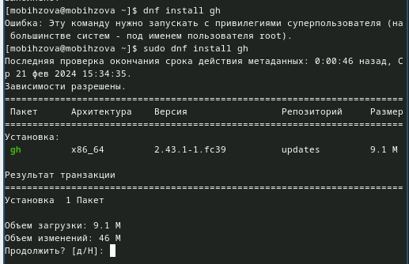

Установка gh

## Базовая настройка git.

Задаю имя и email владельца репозитория (рис. 3).

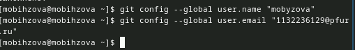

Задаю имя и email владельца репозитория

## Базовая настройка git.

Настраиваю utf-8 в выводе сообщений git (рис. 4]).

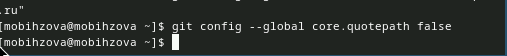

Настройка utf-8 в выводе сообщений git

## Базовая настройка git.

Зададаю имя начальной ветки (будем называть её master) (рис. 5).

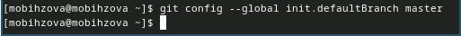

Задаю имя начальной ветки

## Базовая настройка git.

Задаю параметр autocrlf (рис. 6).

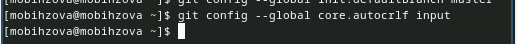

Задаю параметр autocrlf

## Базовая настройка git.

Задаю параметр safecrlf (рис. 7).

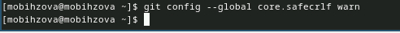

Задаю параметр safecrlf

## Создание ключа ssh.

Создаю ключ ssh по алгоритму rsa с ключём размером 4096 бит (рис. 8).

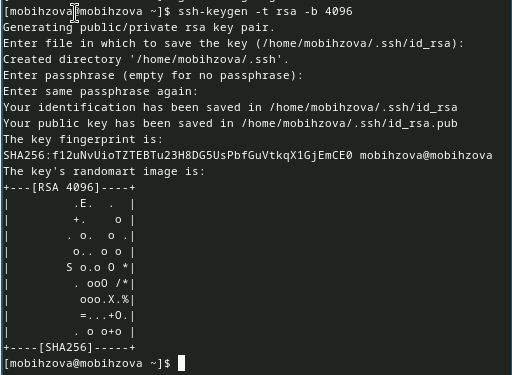

Генерация ключа ssh по алгоритму rsa

## Создание ключа ssh.

Создаю ключ ssh по алгоритму ed25519 (рис. 9).

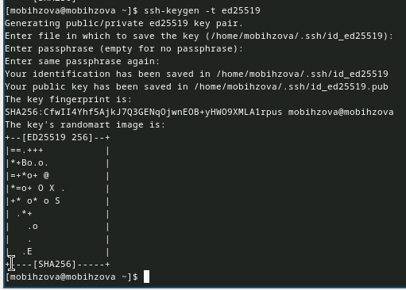

Генерация ключа ssh по алгоритму ed25519

## Создание ключа PGP.

Генерирую ключ PGP, затем выбираю тип ключа RSA and RSA, задаю максимальную длину ключа: 4096, оставляю неограниченный срок действия ключа. Далее отвечаю на вопросы программы о личной информации (рис. 10).

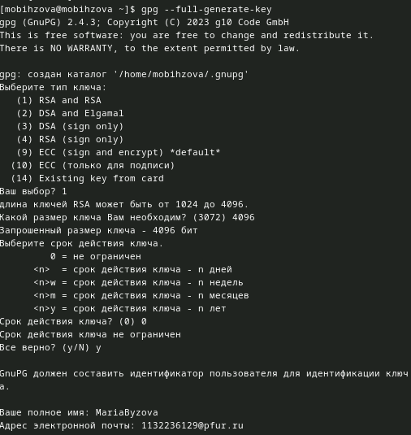

Генерация ключа

## Настройка github.

У меня уже был создан аккаунт на Github, соответсвенно, основные данные аккаунта я так же заполняла и проводила его настройку, поэтому просто вхожу в свой аккаунт (рис. 11).

[figure not shown]

Аккаунт Github

## Добавление ключа PGP в Github

Вывожу список ключей и копирую отпечаток приватного ключ (рис. 12).

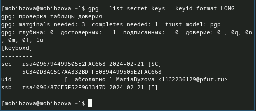

Вывод списка ключей

## Добавление ключа PGP в Github

Cкопирую мой сгенерированный PGP ключ в буфер обмена (рис. 13).

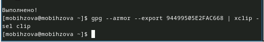

Копирование ключа в буфер обмена

## Добавление ключа PGP в Github

Перейду в настройки GitHub, нажму на кнопку New GPG key и вставлю полученный ключ в поле ввода (рис. 14).

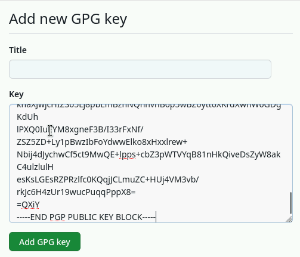

Добавление нового ключа

## Настройка автоматических подписей коммитов git.

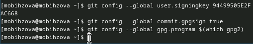

Настройка подписей git

## Настройка gh.

Для начала авторизируюсь: отвечаю на наводящие вопросы от утилиты, в конце выбираю авторизироваться через браузер (рис. 16).

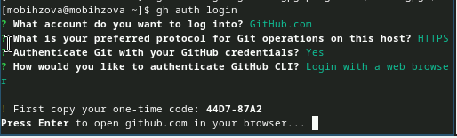

Авторизация

## Настройка gh.

Завершаю авторизацию на сайте (рис. 17).

[figure not shown]

Завершение авторизации

## Настройка gh.

Авторизация прошла успешно (рис. 18).

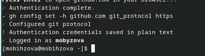

Результат авторизации

## Создание репозитория курса на основе шаблона.

Сначала создаю директорию с помощью утилиты mkdir и флага -p, который позволяет установить каталоги на всем указанном пути. После этого с помощью утилиты cd перехожу в только что созданную директорию (рис. 19).

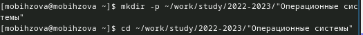

Создание и перемещение между директориями

## Создание репозитория курса на основе шаблона.

Далее создаю репозиторий на основе шаблона репозитория (рис. 20).

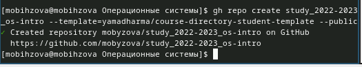

Создание репозитория на основе шаблона репозитория

## Создание репозитория курса на основе шаблона.

Клонирую репозиторий (рис. 21).

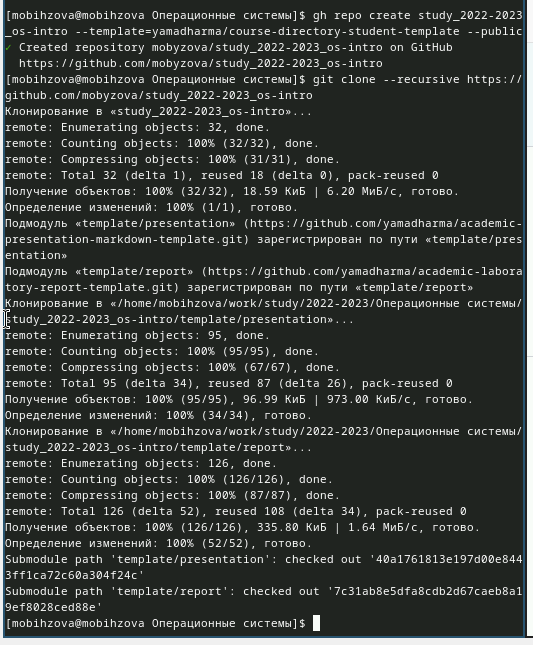

Клонирование репозитория

## Настройка каталога курса.

Перехожу в каталог курса (рис. 22).

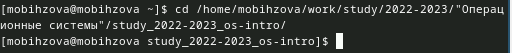

Перемещение между директориями

## Настройка каталога курса.

Удаляю лишние файлы (рис. 23).

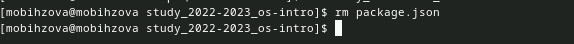

Удаление лишних файлов

## Настройка каталога курса.

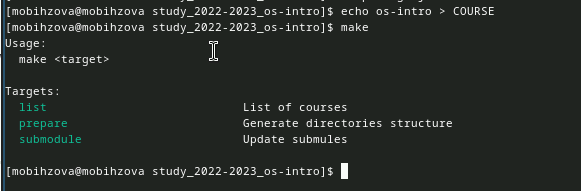

## Настройка каталога курса.

Отправляю файлы на сервер (рис. 25).

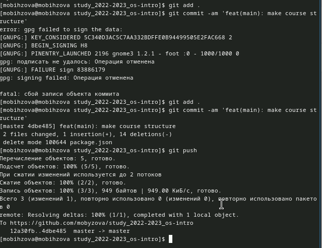

Отправка файлов на сервер

## Выводы

В ходе выполнения данной лабораторной работы я изучила идеологию и применение средств контроля версий, освоила умения по работе с git.

## Список литературы

1. Лабораторная работа №2 [Электронный ресурс] URL: https://esystem.rudn.ru/mod/page/view.php?id=1098933#org2c71102